# Google trends ARIMAX models

Christian Url

Last Compiled Januar 26, 2023

## 0.1 load Packages

```r
library(data.table)
library(lubridate)
library(caret)
library(rai)
library(forecast)
library(parallel)
library(doParallel)
library(tidyverse)
#library(fable) #also  has a forecast and accuracy method!!
```

## 0.2 Paths

```r
datapath = "../data/"
trends_path = paste0(datapath, "googleTrendsAuto/")
ind_path = paste0(datapath, "indicators/")
```

## 0.3 Functions

```r
scale2 <- function(x, na.rm = TRUE) (x - mean(x, na.rm = na.rm)) / sd(x, na.rm)
```

# 1 Read data

## Volatility Index

```r
vol_ind = read_delim(paste0(datapath,"country_volatility_index.csv")) %>%
  mutate(geo = str_split(Countries, " ", simplify = T)[,1], .before = 1,
         country = str_remove(Countries, ".*\\("),
         country = str_extract(country, ".*(?=\\))"))

country_code_list = unlist(vol_ind$geo)
country_list = unlist(vol_ind$country)
country_code_list[country_list=="Greece"] <- "GR"
```

## Trends (containing indicator)

```r
trends_100 = read_csv(paste0(datapath,"trends_100.csv"))
trends_norm = read_csv(paste0(datapath,"trends_norm.csv"))

ind_stats = read_csv(paste0(datapath,"indicator_stats.csv"))
ind_wide = read_csv(paste0(datapath,"indicator_wide.csv"))
```

# 2 Data Issues

Some contries lack a lot of data. Hence, investigating this leads to the following:

```r
s1 = ind_wide %>%
  group_by(geo) %>%
  summarise(min_date = min(month_end),
            max_date = max(month_end),
            na_sum = sum(is.na(resid_TOTAL)),
            n = n()) %>%
  mutate(mon = max_date - min_date,
         y = mon/30)

print(s1, n=nrow(s1))
```

```
# A tibble: 24 × 7
   geo   min_date   max_date   na_sum     n mon        y
   <chr> <date>     <date>      <int> <int> <drtn>     <drtn>
 1 AT    1990-01-01 2022-11-01      0   394 11992 days 399.7333 days
 2 BE    1990-01-01 2022-11-01      0   395 11992 days 399.7333 days
 3 CY    1990-01-01 2022-10-01    108   382 11961 days 398.7000 days
 4 CZ    2002-01-01 2022-11-01      0   251  7609 days 253.6333 days
 5 DE    1990-01-01 2022-11-01      0   395 11992 days 399.7333 days
 6 DK    1990-03-01 2022-11-01      0   391 11933 days 397.7667 days
 7 ES    1990-01-01 2022-11-01      0   395 11992 days 399.7333 days
 8 FI    1990-01-01 2022-11-01      0   395 11992 days 399.7333 days
 9 FR    1994-05-01 2022-11-01      0   235 10411 days 347.0333 days
10 GR    1994-01-01 2022-11-01      4   347 10531 days 351.0333 days
11 HR    2003-01-01 2022-11-01      0   239  7244 days 241.4667 days
12 HU    2001-01-01 2022-11-01      0   263  7974 days 265.8000 days
13 IT    1990-01-01 2022-11-01      0   395 11992 days 399.7333 days
14 LT    2004-01-01 2022-11-01      0   227  6879 days 229.3000 days
15 LU    1990-01-01 2022-11-01      0   395 11992 days 399.7333 days
16 LV    2003-01-01 2022-11-01      0   239  7244 days 241.4667 days
17 MT    1994-01-01 2022-11-01    120   332 10531 days 351.0333 days
18 NL    1990-01-01 2022-11-01      0   395 11992 days 399.7333 days
19 PL    2003-01-01 2022-11-01      0   239  7244 days 241.4667 days
20 PT    1990-01-01 2022-11-01      0   395 11992 days 399.7333 days
21 RO    2002-01-01 2022-11-01      0   251  7609 days 253.6333 days
22 SE    1990-01-01 2022-10-01      0   394 11961 days 398.7000 days
23 SI    2000-01-01 2022-11-01      0   275  8340 days 278.0000 days
24 SK    2003-01-01 2022-11-01      0   239  7244 days 241.4667 days
```

```r
a = ind_wide  %>%
  group_by(geo, year) %>%
  summarise(cnt = sum(!is.na(resid_TOTAL))) %>%
  filter(cnt != 12 & year != 2022) %>%
  ungroup()

print(a, n=nrow(a))
```

```
# A tibble: 44 × 3
   geo    year   cnt
   <chr> <dbl> <int>
 1 AT     2008    11
 2 CY     1990     0
 3 CY     1991     0
 4 CY     1992     0
 5 CY     1993     0
 6 CY     1994     0
 7 CY     1995     0
 8 CY     1996     0
 9 CY     1997     0
10 CY     1998     0
11 DK     1990     8
12 FR     1994     5
```

[output cut: 32 more lines]

# 3 ARIMAX Modeling Intro

Idea: Test variables in a stepwise procedure s.t. only the relevant terms are included in final model Also use the hints discussed here: https://math.unm.edu/~lil/Stat581/10-dynamic-regression.pdf and https://www.r-bloggers.com/2021/10/dynamic-regression-with-arima-errors-the-students-on-the-streets/

Main Ideas:

- Try Fourier part with $K \in 1,2,...,6,12$
- Trend, Drift, Season in extra terms or are they already included?
- The *fable* package (https://fable.tidyverts.org/) should be an easy way to tidy up the estimation process
- Should we use the RAI Package to identify the regression part?

Readings:

- ARIMA Chapter: https://otexts.com/fpp2/arima.html
- Dynamic regression: https://otexts.com/fpp2/dynamic.html
- Neural network models: https://otexts.com/fpp2/nnetar.html

# 4 Fourier transforms

Cannot use standardised series, use log instead. The calculation of Fourier series requires a log-transform of the data, which is not possible for standardised data.

## Example 1

Set up data:

```r
i = 1
trends = trends_norm

c_code = country_code_list[i]
ctry = country_list[i]

ts_set = ind_wide %>%
  filter(geo == c_code) %>%
  zoo::na.locf() %>%
  summarise(year_min = year(min(ind_wide$month_end)), month_min = month(min(ind_wide$month_end)))

ind_ts = ind_wide %>%
  filter(geo == c_code) %>%
  zoo::na.locf() %>%
  select(resid_TOTAL) %>%
  mutate(resid_TOTAL = log(resid_TOTAL)) %>%
  ts(start=c(ts_set$year_min, ts_set$month_min), frequency=12)
```

Benchmark:

```r
ind_ts2 = ind_wide %>%
  filter(geo == c_code) %>%
  zoo::na.locf() %>%
  select(resid_TOTAL_STD) %>%
  ts(start=c(year(min(ind_wide$month_end)),month(min(ind_wide$month_end))), frequency=12)


mod = auto.arima(ind_ts)
forecast::accuracy(mod)
```

```
                       ME      RMSE       MAE         MPE      MAPE      MASE
Training set -0.001674496 0.2479576 0.1207571 -0.03049621 0.7929202 0.7157237
                    ACF1
Training set 0.006700303
```

```r
mod
```

```
Series: ind_ts
ARIMA(1,0,2)(0,1,1)[12]

Coefficients:
         ar1     ma1     ma2     sma1
      0.5600  0.3778  0.2050  -0.6377
s.e.  0.0724  0.0787  0.0711   0.0367

sigma^2 = 0.06409:  log likelihood = -18.88
AIC=47.76   AICc=47.92   BIC=67.48
```

```r
mod2 = auto.arima(ind_ts2)
forecast::accuracy(mod2)
```

```
                      ME      RMSE       MAE       MPE     MAPE      MASE
Training set 0.003383273 0.3297727 0.1944566 -173.1141 282.8342 0.7950608
                   ACF1
Training set 0.01358432
```

```r
mod2
```

```
Series: ind_ts2
ARIMA(1,0,5)(0,1,1)[12]

Coefficients:
         ar1      ma1      ma2      ma3      ma4     ma5     sma1
      0.8727  -0.2004  -0.0511  -0.2571  -0.0913  0.1359  -0.5411
s.e.  0.0485   0.0713   0.0656   0.0571   0.0623  0.0591   0.0443

sigma^2 = 0.1143:  log likelihood = -126.56
AIC=269.13   AICc=269.52   BIC=300.69
```

Calculate a few models:

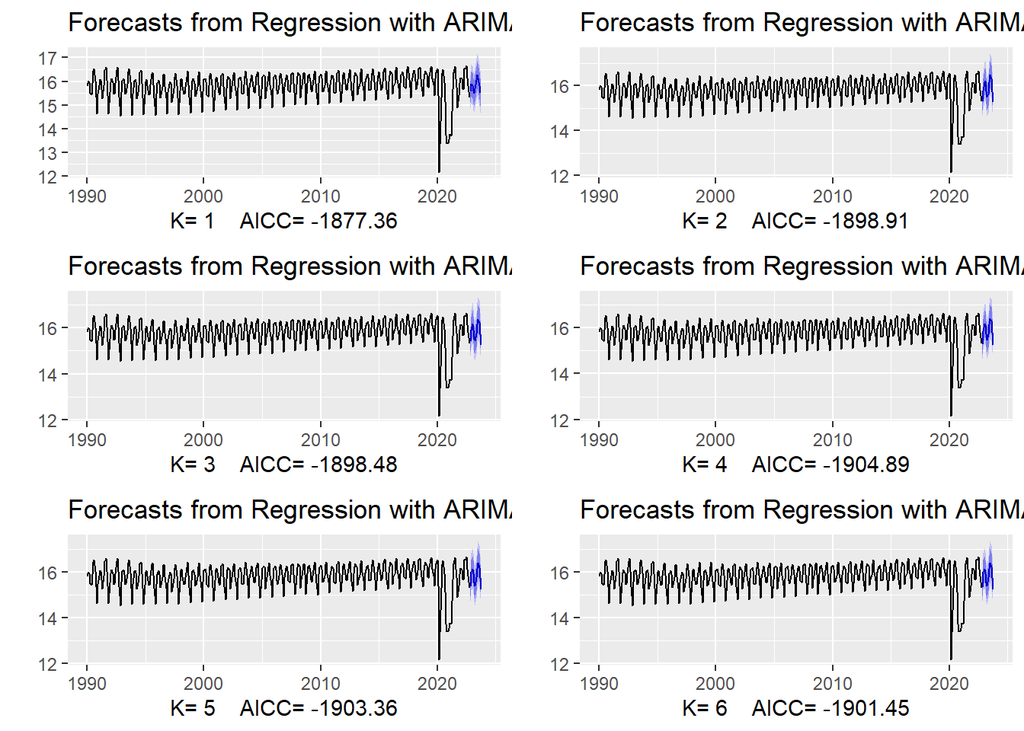

```r
plots <- list()
mod_out = list()
stats_list = list()

for (j in seq(6)) {
  mod_out[[j]] <- auto.arima(ind_ts, xreg = fourier(ind_ts, K = j),
    seasonal = FALSE, lambda = 0)
  plots[[j]] <- autoplot(forecast(mod_out[[j]],
      xreg=fourier(ind_ts, K=j, h=12))) +
    xlab(paste("K=",j,"   AICC=",round(mod_out[[j]][["aicc"]],2))) +
    ylab("")
  stats_list[[j]] = tibble(bic=mod_out[[j]]$bic, aicc=mod_out[[j]]$aicc, sigma2=mod_out[[j]]$sigma2, loglik=mod_out[[j]]$loglik)
}
gridExtra::grid.arrange(
  plots[[1]],plots[[2]],plots[[3]],
  plots[[4]],plots[[5]],plots[[6]], ncol=2)
```

```r
do.call(rbind, stats_list)
```

```
# A tibble: 6 × 4
     bic   aicc   sigma2 loglik
   <dbl>  <dbl>    <dbl>  <dbl>
1 -1842. -1877. 0.000481   948.
2 -1852. -1899. 0.000455   962.
3 -1848. -1898. 0.000454   963.
4 -1843. -1905. 0.000443   969.
5 -1837. -1903. 0.000443   969.
6 -1832. -1901. 0.000444   970.
```

```r
do.call(rbind, map(mod_out, forecast::accuracy))
```

```
                      ME      RMSE       MAE         MPE     MAPE     MASE
Training set 0.004701564 0.3202960 0.1969550 -0.01890902 1.286578 1.167346
Training set 0.004235428 0.3116135 0.1965441 -0.01803288 1.280952 1.164911
Training set 0.003830966 0.3103761 0.1923772 -0.01891285 1.256354 1.140214
Training set 0.004219022 0.3056214 0.1913295 -0.01662072 1.246075 1.134004
Training set 0.003647156 0.3048095 0.1882493 -0.01874148 1.228186 1.115748
Training set 0.003636613 0.3047794 0.1882007 -0.01877227 1.227575 1.115460
                    ACF1
Training set 0.072388230
Training set 0.013764076
Training set 0.003352199
Training set 0.010210982
Training set 0.006364498
Training set 0.005623690
```

## Country-wise ARIMAX with Fourier

```r
cl = detectCores()-1
registerDoParallel(cl)

res_list = foreach(i = 1:length(country_code_list), .packages=c("tidyverse","forecast", "lubridate"), .multicombine = T, .combine = rbind) %dopar% {

  # Data

  c_code = country_code_list[i]
  ctry = country_list[i]

  ts_set = ind_wide %>%
    filter(geo == c_code) %>%
    zoo::na.locf() %>%
    summarise(year_min = year(min(month_end)), month_min = month(min(month_end)))

  if (c_code == "FR"){ts_set = tibble(year_min = 2010, month_min = 1)}
  if (c_code == "CY"){ts_set = tibble(year_min = 2000, month_min = 1)}
  if (c_code == "DK"){ts_set = tibble(year_min = 2007, month_min = 1)}
  if (c_code == "MT"){ts_set = tibble(year_min = 2010, month_min = 1)}

  ind_ts = ind_wide %>%
    filter(geo == c_code & year >= ts_set$year_min) %>%
    zoo::na.locf() %>%
    select(resid_TOTAL) %>%
    mutate(resid_TOTAL = log(resid_TOTAL)) %>%
    ts(start=c(ts_set$year_min, ts_set$month_min), frequency=12)

  # Fourier models

  for (j in seq(6)) {
    mod_out[[j]] <- auto.arima(ind_ts, xreg = fourier(ind_ts, K = j), seasonal = FALSE, lambda = 0)

    stats_list[[j]] = tibble(bic=mod_out[[j]]$bic, aicc=mod_out[[j]]$aicc, sigma2=mod_out[[j]]$sigma2, loglik=mod_out[[j]]$loglik)

  }
  stats = do.call(rbind, stats_list)
  acc = do.call(rbind, map(mod_out, forecast::accuracy))

  # Determine best Fourier mod
  f_ord = which(stats$aicc == min(stats$aicc))
  mod = mod_out[[f_ord]]
  pred = forecast(mod_out[[f_ord]], xreg=fourier(ind_ts, K=f_ord, h=4))

  # Predictions
  yhat = exp(pred$mean)
  coefs = as.data.frame(coef(mod)) %>%
    rownames_to_column(var = "coef") %>%
    rename(val = `coef(mod)`) %>%
    pivot_wider(names_from = coef, values_from = val) %>%
    add_column(geo = c_code, .before = 1) %>%
    add_column(sigma = mod$sigma2)

  arima_order = as.data.frame(arimaorder(mod)) %>%
    rownames_to_column(var = "coef") %>%
    rename(val = `arimaorder(mod)`) %>%
    pivot_wider(names_from = coef, values_from = val) %>%
    add_column(geo = c_code, .before = 1)

  # Final export
  yhat_list = list(tibble(month_end = zoo::as.Date(pred$mean),geo=c_code, yhat = yhat, fourier_order=f_ord,
                          bic = mod$bic, aicc = mod$aicc, sigma2 = mod$sigma2, loglik  = mod$loglik,
                          rmse = forecast::accuracy(mod)[2], mae = forecast::accuracy(mod)[3], acf = forecast::accuracy(mod)[7]),
                          coefs,
                          arima_order)
}

res_df_fourier = do.call(bind_rows, res_list[,1])
coefs_df_fourier = do.call(bind_rows, res_list[,2])
arima_order_df_fourier = do.call(bind_rows, res_list[,3])

stopImplicitCluster()

res_df_fourier
```

```
# A tibble: 96 × 11
   month_end  geo        yhat fourier…¹    bic   aicc  sigma2 loglik  rmse   mae
   <date>     <chr>     <dbl>     <int>  <dbl>  <dbl>   <dbl>  <dbl> <dbl> <dbl>
 1 2022-11-01 AT     4282447.         4 -1843. -1905. 4.43e-4   969. 0.306 0.191
 2 2022-12-01 AT     7562451.         4 -1843. -1905. 4.43e-4   969. 0.306 0.191
 3 2023-01-01 AT    10510297.         4 -1843. -1905. 4.43e-4   969. 0.306 0.191
 4 2023-02-01 AT    10318286.         4 -1843. -1905. 4.43e-4   969. 0.306 0.191
 5 2022-12-01 BE     2127450.         6 -2032. -2091. 2.76e-4  1061. 0.214 0.114
 6 2023-01-01 BE     1314301.         6 -2032. -2091. 2.76e-4  1061. 0.214 0.114
 7 2023-02-01 BE     1590845.         6 -2032. -2091. 2.76e-4  1061. 0.214 0.114
 8 2023-03-01 BE     1887662.         6 -2032. -2091. 2.76e-4  1061. 0.214 0.114
 9 2022-11-01 CY      558965.         6  -897.  -949. 1.68e-3   491. 0.414 0.173
10 2022-12-01 CY      257120.         6  -897.  -949. 1.68e-3   491. 0.414 0.173
# … with 86 more rows, 1 more variable: acf <dbl>, and abbreviated variable
#   name ¹fourier_order
```

Export:

```r
write_csv(res_df_fourier, file=paste0(datapath,"results/arimax_fourier_forecasts.csv"))
write_csv(coefs_df_fourier, file=paste0(datapath,"results/arimax_fourier_forecasts_coefs.csv"))
write_csv(arima_order_df_fourier, file=paste0(datapath,"results/arimax_fourier_forecasts_order.csv"))
```

## Results

```r
overview = res_df_fourier %>%
  group_by(geo) %>%
  summarise(min_date = min(month_end), max_date = max(month_end), bic = min(bic), rmse = min(rmse), mae = min(mae), acf = min(acf))

print(overview, n = nrow(overview))
```

```
# A tibble: 24 × 7
   geo   min_date   max_date      bic  rmse    mae      acf
   <chr> <date>     <date>      <dbl> <dbl>  <dbl>    <dbl>
 1 AT    2022-11-01 2023-02-01 -1843. 0.306 0.191   0.0102
 2 BE    2022-12-01 2023-03-01 -2032. 0.214 0.114   0.00855
 3 CY    2022-11-01 2023-02-01  -897. 0.414 0.173  -0.0262
 4 CZ    2022-12-01 2023-03-01 -1214. 0.242 0.106   0.0573
 5 DE    2022-12-01 2023-03-01 -2553. 0.134 0.0677 -0.00678
 6 DK    2022-12-01 2023-03-01 -1109. 0.157 0.107   0.0603
 7 ES    2022-12-01 2023-03-01 -2352. 0.164 0.0824 -0.416
 8 FI    2022-12-01 2023-03-01 -2542. 0.115 0.0610  0.00908
 9 FR    2022-12-01 2023-03-01  -765. 0.239 0.128  -0.00230
10 GR    2022-12-01 2023-03-01 -1653. 0.260 0.114  -0.00264
11 HR    2022-12-01 2023-03-01 -1083. 0.268 0.144  -0.0111
12 HU    2022-12-01 2023-03-01 -1377. 0.197 0.101   0.0294
13 IT    2022-12-01 2023-03-01 -2553. 0.137 0.0811 -0.0502
14 LT    2022-12-01 2023-03-01 -1310. 0.137 0.0802  0.0197
15 LU    2022-12-01 2023-03-01 -1979. 0.194 0.112   0.00726
16 LV    2022-12-01 2023-03-01 -1414. 0.121 0.0712  0.0284
17 MT    2022-12-01 2023-03-01  -624. 0.286 0.140   0.0314
18 NL    2022-12-01 2023-03-01 -2501. 0.137 0.0851 -0.0481
19 PL    2022-12-01 2023-03-01 -1326. 0.180 0.0877  0.0338
20 PT    2022-12-01 2023-03-01 -2245. 0.171 0.0772  0.0222
21 RO    2022-12-01 2023-03-01 -1344. 0.176 0.102   0.0126
22 SE    2022-11-01 2023-02-01 -2656. 0.106 0.0739  0.0237
23 SI    2022-12-01 2023-03-01 -1242. 0.245 0.126   0.0388
24 SK    2022-12-01 2023-03-01 -1155. 0.220 0.101   0.0633
```

coefficients:

```r
print(xtable::xtable(coefs_df_fourier), type="html")
```

|  | geo | ar1 | ma1 | ma2 | ma3 | ma4 | ma5 | intercept | S1-12 | C1-12 | S2-12 | C2-12 | S3-12 | C3-12 | S4-12 | C4-12 | sigma | S5-12 | C5-12 | C6-12 | ar2 | ar3 | ar4 | ar5 | drift |
| --- | --- | --- | --- | --- | --- | --- | --- | --- | --- | --- | --- | --- | --- | --- | --- | --- | --- | --- | --- | --- | --- | --- | --- | --- | --- |
| 1 | AT | 0.90 | -0.17 | -0.20 | -0.27 | -0.20 | 0.25 | 2.76 | -0.00 | -0.01 | 0.03 | 0.01 | 0.00 | 0.00 | -0.00 | 0.00 | 0.00 |  |  |  |  |  |  |  |  |
| 2 | BE |  | 0.14 | -0.66 | -0.41 |  |  |  | -0.02 | -0.03 | 0.01 | -0.00 | -0.01 | 0.01 | 0.00 | -0.01 | 0.00 | 0.00 | 0.01 | 0.00 |  |  |  |  |  |
| 3 | CY | 0.44 | -0.32 | -0.63 |  |  |  |  | -0.06 | -0.05 | -0.00 | -0.01 | -0.00 | -0.01 | 0.00 | 0.00 | 0.00 | 0.01 | 0.00 | 0.00 |  |  |  |  |  |
| 4 | CZ | 0.66 | 0.35 |  |  |  |  | 2.71 | -0.02 | -0.02 | 0.01 | -0.00 | -0.00 | -0.00 | -0.00 | -0.00 | 0.00 | 0.00 | 0.00 |  |  |  |  |  |  |
| 5 | DE | 0.73 | -0.59 |  |  |  |  |  | -0.02 | -0.02 | 0.00 | -0.00 | 0.00 | -0.00 | 0.00 | -0.00 | 0.00 | 0.00 | 0.00 | 0.00 | -0.42 | 0.08 | -0.09 | -0.16 |  |
| 6 | DK | 0.76 |  |  |  |  |  | 2.67 | -0.03 | -0.05 | 0.01 | 0.00 | -0.01 | 0.01 | 0.00 | -0.00 | 0.00 | -0.00 | 0.01 |  |  |  |  |  |  |
| 7 | GR | 0.45 | -0.36 | -0.41 | -0.18 |  |  |  | -0.06 | -0.07 | 0.01 | -0.01 | 0.01 | -0.00 | 0.00 | 0.00 | 0.00 | 0.01 | 0.01 | 0.00 |  |  |  |  |  |
| 8 | ES | 0.04 | 0.56 |  |  |  |  |  | -0.02 | -0.03 | 0.01 | -0.01 | -0.00 | 0.00 | 0.00 | -0.00 | 0.00 | 0.00 | 0.00 | 0.00 |  |  |  |  | 0.00 |
| 9 | FI | 0.57 | -0.56 | -0.39 |  |  |  |  | -0.01 | -0.02 | 0.01 | 0.00 | -0.01 | -0.00 | 0.00 | 0.00 | 0.00 | -0.00 | 0.00 | -0.00 |  |  |  |  | 0.00 |
| 10 | FR | 0.02 | 0.11 | -0.73 |  |  |  |  | -0.02 | -0.03 | 0.02 | -0.00 | -0.00 | 0.01 | -0.00 | -0.00 | 0.00 | 0.00 | 0.00 | 0.00 | 0.21 | -0.30 |  |  |  |
| 11 | HR | 0.76 | -0.76 |  |  |  |  |  | -0.08 | -0.11 | 0.02 | -0.01 | 0.01 | 0.01 | 0.00 | 0.00 | 0.00 | 0.00 | 0.00 | 0.00 | -0.43 |  |  |  |  |
| 12 | HU | 0.92 | -0.74 |  |  |  |  |  | -0.03 | -0.03 | 0.01 | -0.00 | -0.01 | 0.00 | -0.00 | -0.00 | 0.00 | 0.01 | 0.00 |  | -0.44 |  |  |  |  |
| 13 | IT | 1.07 | -0.77 |  |  |  |  |  | -0.03 | -0.04 | 0.02 | -0.01 | 0.00 | 0.00 | 0.00 | -0.00 | 0.00 | 0.00 | 0.00 | 0.00 | -0.52 |  |  |  |  |
| 14 | LT | 1.00 | -0.73 |  |  |  |  |  | -0.03 | -0.03 | 0.01 | 0.00 | -0.00 | 0.00 | -0.00 | -0.00 | 0.00 | 0.00 | 0.00 |  | -0.45 |  |  |  |  |
| 15 | LU | -0.02 | 0.78 |  |  |  |  | 2.49 | -0.03 | -0.05 | 0.01 | 0.00 | -0.01 | 0.01 | -0.00 | -0.01 | 0.00 | 0.01 | 0.01 |  | 0.40 |  |  |  |  |
| 16 | LV | 1.85 | -1.73 | 0.86 |  |  |  |  | -0.02 | -0.03 | 0.01 | 0.00 | -0.00 | 0.00 | 0.00 | -0.00 | 0.00 | 0.00 | 0.00 | 0.00 | -1.36 | 0.36 |  |  |  |
| 17 | MT | 0.99 | -0.69 |  |  |  |  |  | -0.03 | -0.02 | 0.01 | -0.01 | -0.01 | -0.00 | 0.00 | -0.00 | 0.00 | 0.00 | 0.00 |  | -0.53 |  |  |  |  |
| 18 | NL | 1.53 | -1.76 | 0.88 |  |  |  |  | -0.02 | -0.04 | 0.00 | -0.00 | -0.00 | 0.01 | -0.00 | -0.01 | 0.00 | 0.00 | 0.00 | 0.00 | -0.81 |  |  |  |  |
| 19 | PL | 0.91 | -0.78 |  |  |  |  |  | -0.02 | -0.02 | 0.01 | -0.00 | -0.00 | -0.00 | -0.00 | -0.00 | 0.00 | 0.00 | 0.00 |  | -0.41 |  |  |  |  |
| 20 | PT | 0.66 | -0.52 | -0.45 |  |  |  |  | -0.03 | -0.03 | 0.01 | -0.01 | -0.00 | 0.00 | -0.00 | -0.00 | 0.00 | 0.00 | 0.00 | 0.00 |  |  |  |  |  |
| 21 | RO | 0.42 | 1.03 | 0.21 |  |  |  | 2.65 | -0.03 | -0.02 | 0.01 | 0.00 | -0.01 | 0.00 | -0.00 | -0.00 | 0.00 | 0.00 | 0.00 | 0.00 |  |  |  |  |  |
| 22 | SE | 1.69 | -1.76 | 1.66 | -0.86 |  |  |  | -0.01 | -0.03 | 0.01 | 0.00 | -0.01 | -0.00 | 0.00 | -0.00 | 0.00 | 0.00 | 0.00 | -0.00 | -1.65 | 0.71 |  |  | 0.00 |
| 23 | SI | 0.95 | -0.71 |  |  |  |  |  | -0.03 | -0.03 | 0.02 | -0.00 | -0.00 | 0.00 | -0.00 | -0.00 | 0.00 | 0.00 | 0.00 | 0.00 | -0.68 | 0.31 | -0.27 |  |  |
| 24 | SK | 0.65 | 0.37 |  |  |  |  | 2.62 | -0.02 | -0.02 | 0.02 | -0.00 | -0.00 | -0.00 | -0.00 | -0.00 | 0.00 | 0.00 | 0.00 | -0.00 |  |  |  |  |  |

# 5 Arimax models with google data

** NO CACHE FOR NEW PARTS **

```r
knitr::opts_chunk$set(cache = FALSE)
```

Plan:

- Add lags of variables
- Try all combinations of vars and lags

# 6 Arimax models using formula from RAI

Idea: Instead of excessively searching a parameter space without a testing procedure, try to use all combinations in a rai model and then use the formula in an auto.arima model.

## 6.1 Example 1 (AT)

```r
# Set up lagged predictors
lags = c(0:11)
i = 1

c_code = country_code_list[i]
ctry = country_list[i]

trends = trends_100 %>%
  select(!resid_TOTAL_STD) %>%
  filter(country_code == c_code) %>%
  zoo::na.locf()

indicator = ind_wide %>%
  filter(geo == c_code) %>%
  rename(country_code = geo, date=month_end) %>%
  zoo::na.locf() %>%
  select(date, country_code, resid_TOTAL)

ts_set = trends %>%
  summarise(year_min = year(min(date)), month_min = month(min(date)), max_date = max(date))

trends2 = indicator %>%
  mutate(resid_TOTAL = log(resid_TOTAL)) %>%
  inner_join(trends, by=c("date", "country_code")) %>%
  select(-c(date, country_code)) %>%
  ts(start=c(ts_set$year_min, ts_set$month_min), frequency=12)


lag_trends_ts = function(lags, input_ts, col_pos){
  stopifnot(is.ts(input_ts))

  out = list()
  lags_neg = -1*lags

  for(i in seq_along(col_pos)){
    col_sel = col_pos[i]
    t_out = list()
    for(j in seq_along(lags)){
      t_out[[j]] = stats::lag(input_ts[,col_sel],lags_neg[j])
    }
    out[[i]] = do.call(cbind,t_out)
    if(ncol(out[[i]]) > 1){
      colnames(out[[i]]) = paste0(colnames(input_ts)[col_sel], "_lag", lags)
    }
    out[[i]] = fable::as_tsibble(out[[i]]) #need this for binding the data accurately
  }
  res = as.ts(do.call(bind_rows,out))
  return(res)
}

trends_ts_lag = lag_trends_ts(lags=c(0:11),input_ts=trends2,col_pos = c(2:12))
theData = trends_ts_lag[13:221,]
theResponse = trends2[13:221,1]

rai_out = rai(theData = theData, theResponse = theResponse)
summary(rai_out$model)
```

```
Call:
lm(formula = aucOut$formula, data = data.frame(y = theResponse,
    aucOut$subData))

Residuals:
     Min       1Q   Median       3Q      Max
-1.18630 -0.15377  0.00685  0.17365  0.64899

Coefficients:
                         Estimate Std. Error t value Pr(>|t|)
(Intercept)              18.52686    0.26802  69.126  < 2e-16 ***
I(country_cc_trav_lag3)  -0.23972    0.37997  -0.631 0.528887
I(country_trav_lag0)      1.17274    0.32225   3.639 0.000354 ***
I(country_hike_lag9)     -0.44703    0.22226  -2.011 0.045742 *
I(country_cc_trav_lag9)  -1.54304    0.31679  -4.871 2.37e-06 ***
I(cc_restaurant_lag1)     2.87987    0.45673   6.305 2.04e-09 ***
I(cc_groc_lag9)           0.53532    0.38102   1.405 0.161697
I(cc_groc_lag11)         -2.23837    0.34960  -6.403 1.21e-09 ***
I(cc_fooddrink_lag1)     -1.88957    0.53097  -3.559 0.000473 ***
I(country_trav_lag10)     0.02293    0.33722   0.068 0.945872
I(country_hotels_lag4)   -1.53676    0.46893  -3.277 0.001251 **
I(country_hike_lag7)      0.62758    0.20843   3.011 0.002966 **
I(cc_restaurant_lag0)     2.47997    0.42615   5.819 2.54e-08 ***
I(cc_fooddrink_lag0)     -2.22757    0.53278  -4.181 4.46e-05 ***
I(country_trav_lag6)      1.17828    0.30907   3.812 0.000187 ***
I(country_hotels_lag3)   -1.52922    0.51787  -2.953 0.003554 **
I(country_cc_trav_lag1)  -1.79076    0.36639  -4.888 2.20e-06 ***
I(country_trav_lag7)      0.84523    0.32555   2.596 0.010176 *
I(country_trav_gui_lag8)  0.65329    0.21046   3.104 0.002206 **
I(country_hotels_lag10)  -1.55766    0.37534  -4.150 5.06e-05 ***
I(country_hotels_lag1)    2.08221    0.49183   4.234 3.61e-05 ***
I(country_car_rent_lag3) -1.73553    0.47048  -3.689 0.000296 ***
I(cc_groc_lag10)         -0.90401    0.33593  -2.691 0.007771 **
---
Signif. codes:  0 '***' 0.001 '**' 0.01 '*' 0.05 '.' 0.1 ' ' 1

Residual standard error: 0.2837 on 186 degrees of freedom
Multiple R-squared:  0.8288,    Adjusted R-squared:  0.8085
F-statistic: 40.92 on 22 and 186 DF,  p-value: < 2.2e-16
```

```r
f_rai = formula(rai_out$formula)

mod = auto.arima(y=theResponse, xreg = rai_out$X[,-1])
mod
```

```
Series: theResponse
Regression with ARIMA(1,0,0) errors

Coefficients:
         ar1  intercept  I(country_cc_trav_lag3)  I(country_trav_lag0)
      0.3746    18.4306                  -0.0759                0.7263
s.e.  0.0719     0.3035                   0.3668                0.2906
      I(country_hike_lag9)  I(country_cc_trav_lag9)  I(cc_restaurant_lag1)
                   -0.4360                  -1.3486                 3.3256
s.e.                0.2062                   0.2977                 0.4107
      I(cc_groc_lag9)  I(cc_groc_lag11)  I(cc_fooddrink_lag1)
               0.3347           -2.2790               -2.1221
s.e.           0.3286            0.3067                0.4459
      I(country_trav_lag10)  I(country_hotels_lag4)  I(country_hike_lag7)
                    -0.0514                 -1.4361                0.6145
s.e.                 0.2897                  0.3869                0.1922
      I(cc_restaurant_lag0)  I(cc_fooddrink_lag0)  I(country_trav_lag6)
                     2.3224               -2.0821                1.2483
s.e.                 0.3665                0.4398                0.2698
      I(country_hotels_lag3)  I(country_cc_trav_lag1)  I(country_trav_lag7)
                     -1.5083                  -1.8674                0.9241
s.e.                  0.4321                   0.3470                0.2827
      I(country_trav_gui_lag8)  I(country_hotels_lag10)  I(country_hotels_lag1)
                        0.5662                  -1.3316                  1.9039
s.e.                    0.1929                   0.3592                  0.4541
      I(country_car_rent_lag3)  I(cc_groc_lag10)
                       -1.7893           -0.8988
s.e.                    0.4519            0.2768

sigma^2 = 0.07177:  log likelihood = -8.61
AIC=67.22   AICc=74.32   BIC=150.78
```

```r
accuracy(mod)
```

```
                      ME      RMSE       MAE         MPE     MAPE      MASE
Training set -0.00103191 0.2520553 0.1929671 -0.03600081 1.236908 0.4763617
                   ACF1
Training set 0.01490307
```

```r
Y = ts(theResponse, start=c(ts_set$year_min+1, ts_set$month_min), frequency = 12)
X_reg = ts(rai_out$X[,-1], start=c(ts_set$year_min+1, ts_set$month_min), frequency = 12)
X_full = ts(theData, start=c(ts_set$year_min+1, ts_set$month_min), frequency = 12)
mod2 = auto.arima(y=Y, xreg = X_reg)
mod2
```

```
Series: Y
Regression with ARIMA(2,0,0)(1,0,0)[12] errors

Coefficients:
         ar1      ar2    sar1  intercept  I(country_cc_trav_lag3)
      0.5842  -0.1999  0.5441    17.9423                   0.4378
s.e.  0.0842   0.0826  0.1062     0.4262                   0.3938
      I(country_trav_lag0)  I(country_hike_lag9)  I(country_cc_trav_lag9)
                   -0.2944               -0.1069                  -0.6823
s.e.                0.2801                0.2375                   0.3649
      I(cc_restaurant_lag1)  I(cc_groc_lag9)  I(cc_groc_lag11)
                     3.8713           0.1162           -1.7062
s.e.                 0.3599           0.3763            0.4261
      I(cc_fooddrink_lag1)  I(country_trav_lag10)  I(country_hotels_lag4)
                   -2.7694                 0.4129                 -1.1611
s.e.                0.4937                 0.2714                  0.3946
      I(country_hike_lag7)  I(cc_restaurant_lag0)  I(cc_fooddrink_lag0)
                    0.3128                 2.0203               -2.1029
s.e.                0.2482                 0.3593                0.4698
      I(country_trav_lag6)  I(country_hotels_lag3)  I(country_cc_trav_lag1)
                    1.3632                 -1.1737                  -1.6115
s.e.                0.2739                  0.4464                   0.3892
      I(country_trav_lag7)  I(country_trav_gui_lag8)  I(country_hotels_lag10)
                    0.9571                    0.3064                  -0.9847
s.e.                0.2803                    0.1864                   0.3358
      I(country_hotels_lag1)  I(country_car_rent_lag3)  I(cc_groc_lag10)
                      0.7940                   -0.8510           -1.3352
s.e.                  0.4764                    0.4461            0.3686

sigma^2 = 0.06528:  log likelihood = 0.23
AIC=53.55   AICc=61.9   BIC=143.79
```

```r
accuracy(mod2)
```

```
                       ME      RMSE       MAE         MPE     MAPE      MASE
Training set -0.002647705 0.2390846 0.1843887 -0.04329163 1.180752 0.6789763
                    ACF1
Training set -0.01488404
```

We can see that the RAI model has a good training fit. Thus, we’ll need to cross validate this result.

# 7 Neuronal nets from forecasting book for AT

Testing only for Austria. No Preds here. need to calculate X_reg matrix for the months ahead fist. Then, use these as input to NN. Maybe try this in python! https://towardsdatascience.com/temporal-loops-intro-to-recurrent-neural-networks-for-time-series-forecasting-in-python-b0398963dc1f https://towardsdatascience.com/a-quick-deep-learning-recipe-time-series-forecasting-with-keras-in-python-f759923ba64 https://machinelearningmastery.com/time-series-prediction-lstm-recurrent-neural-networks-python-keras/

## Without external regressors

```r
i=1
#cl = detectCores()-1
#registerDoParallel(cl)
#
# res_list = foreach(i = 1:length(country_code_list), .packages=c("tidyverse","forecast", "lubridate"), .multicombine = T, .combine = rbind) %dopar% {
#
  # Data

  c_code = country_code_list[i]
  ctry = country_list[i]

  ts_set = ind_wide %>%
    filter(geo == c_code) %>%
    zoo::na.locf() %>%
    summarise(year_min = year(min(month_end)), month_min = month(min(month_end)))

  if (c_code == "FR"){ts_set = tibble(year_min = 2010, month_min = 1)}
  if (c_code == "CY"){ts_set = tibble(year_min = 2000, month_min = 1)}
  if (c_code == "DK"){ts_set = tibble(year_min = 2007, month_min = 1)}
  if (c_code == "MT"){ts_set = tibble(year_min = 2010, month_min = 1)}

  ind_ts = ind_wide %>%
    filter(geo == c_code & year >= ts_set$year_min) %>%
    zoo::na.locf() %>%
    select(resid_TOTAL) %>%
    mutate(resid_TOTAL = sqrt(resid_TOTAL)) %>%
    ts(start=c(ts_set$year_min, ts_set$month_min), frequency=12)

  # NNETAR models
  mod = nnetar(ind_ts, repeats = 50, size = 20)
  pred = forecast(mod, h=4)

  # Predictions
  yhat = pred$mean^2

  # Final export
  yhat_list = tibble(month_end = zoo::as.Date(pred$mean),geo=c_code, yhat = yhat,
                          bic = mod$bic, aicc = mod$aicc, sigma2 = mod$sigma2, loglik  = mod$loglik,
                          rmse = forecast::accuracy(mod)[2], mae = forecast::accuracy(mod)[3], acf = forecast::accuracy(mod)[7])
  yhat_list
```

```
# A tibble: 4 × 6
  month_end  geo       yhat  rmse   mae     acf
  <date>     <chr>    <dbl> <dbl> <dbl>   <dbl>
1 2022-11-01 AT    6501201.  26.4  17.4 -0.0731
2 2022-12-01 AT    9142767.  26.4  17.4 -0.0731
3 2023-01-01 AT    9559785.  26.4  17.4 -0.0731
4 2023-02-01 AT    8287811.  26.4  17.4 -0.0731
```

```r
#}

#res_df = do.call(bind_rows, res_list)

#stopImplicitCluster()

#res_df
```

## Using external regressors without lags

No Preds here. need to calculate X_reg matrix for the months ahead fist. Then, use these as input to NN. Maybe try this in python!

```r
i = 1
c_code = country_code_list[i]
ctry = country_list[i]

trends = trends_100 %>%
  select(!resid_TOTAL_STD) %>%
  filter(country_code == c_code) %>%
  zoo::na.locf()

indicator = ind_wide %>%
  filter(geo == c_code) %>%
  rename(country_code = geo, date=month_end) %>%
  zoo::na.locf() %>%
  select(date, country_code, resid_TOTAL)

ts_set = trends %>%
  summarise(year_min = year(min(date)), month_min = month(min(date)), max_date = max(date))

trends2 = indicator %>%
  mutate(resid_TOTAL = sqrt(resid_TOTAL)) %>%
  inner_join(trends, by=c("date", "country_code")) %>%
  select(-c(date, country_code)) %>%
  ts(start=c(ts_set$year_min, ts_set$month_min), frequency=12)

#cl = detectCores()-1
#registerDoParallel(cl)

#res_list = foreach(i = 1:length(country_code_list), .packages=c("tidyverse","forecast", "lubridate"), .multicombine = T, .combine = rbind) %dopar% {

  # Data


  # NNETAR models
  mod = nnetar(trends2[,1], repeats = 20, xreg = trends2[,2:12])
  accuracy(mod)
```

```
                      ME     RMSE      MAE          MPE       MAPE        MASE
Training set -0.02377716 3.335148 1.940438 -0.003469799 0.07068204 0.007414985
                    ACF1
Training set -0.09988414
```

```r
 # pred = forecast(mod, h=4)
  # Predictions
  #yhat = pred$mean^2

  # Final export
  yhat_list = tibble(month_end = zoo::as.Date(pred$mean),geo=c_code,# yhat = yhat,
                          bic = mod$bic, aicc = mod$aicc, sigma2 = mod$sigma2, loglik  = mod$loglik,
                          rmse = forecast::accuracy(mod)[2], mae = forecast::accuracy(mod)[3], acf = forecast::accuracy(mod)[7])
  yhat_list
```

```
# A tibble: 4 × 5
  month_end  geo    rmse   mae     acf
  <date>     <chr> <dbl> <dbl>   <dbl>
1 2022-11-01 AT     3.34  1.94 -0.0999
2 2022-12-01 AT     3.34  1.94 -0.0999
3 2023-01-01 AT     3.34  1.94 -0.0999
4 2023-02-01 AT     3.34  1.94 -0.0999
```

```r
#}

#res_df = do.call(bind_rows, res_list)
#
# stopImplicitCluster()
#
# res_df
```

## Using external regressors

Runtime is an issue, will try this in python.

```r
i = 1
goo = read_csv(paste0(trends_path, "trends_full.csv"))
trends_100 = goo %>%
  mutate(across(3:13, ~.x/100))

ts_set = indicator %>%
  summarise(max_date = max(date))

trends_ts_lag = lag_trends_ts(lags=c(0:11),input_ts=trends2,col_pos = c(2:12))
theData = trends_ts_lag[13:221,]
theResponse = trends2[13:221,1]

#cl = detectCores()-1
#registerDoParallel(cl)

#res_list = foreach(i = 1:length(country_code_list), .packages=c("tidyverse","forecast", "lubridate"), .multicombine = T, .combine = rbind) %dopar% {

  # Data


  # NNETAR models
  mod = nnetar(theResponse, repeats = 5, xreg = theData, MaxNWts=11000, trace=T)
 # pred = forecast(mod, h=4)
  # Predictions
  #yhat = pred$mean^2

  # Final export
  yhat_list = tibble(month_end = zoo::as.Date(pred$mean),geo=c_code,# yhat = yhat,
                          bic = mod$bic, aicc = mod$aicc, sigma2 = mod$sigma2, loglik  = mod$loglik,
                          rmse = forecast::accuracy(mod)[2], mae = forecast::accuracy(mod)[3], acf = forecast::accuracy(mod)[7])
  yhat_list
```

```
# A tibble: 4 × 5
  month_end  geo    rmse   mae   acf
  <date>     <chr> <dbl> <dbl> <dbl>
1 2022-11-01 AT    0.192 0.157 0.107
2 2022-12-01 AT    0.192 0.157 0.107
3 2023-01-01 AT    0.192 0.157 0.107
4 2023-02-01 AT    0.192 0.157 0.107
```

```r
#}

#res_df = do.call(bind_rows, res_list)
#
# stopImplicitCluster()
#
# res_df
```

## Using external regressors from RAI

```r
i = 1
goo = read_csv(paste0(trends_path, "trends_full.csv"))
trends_100 = goo %>%
  mutate(across(3:13, ~.x/100))

ts_set = indicator %>%
  summarise(max_date = max(date))

#cl = detectCores()-1
#registerDoParallel(cl)

#res_list = foreach(i = 1:length(country_code_list), .packages=c("tidyverse","forecast", "lubridate"), .multicombine = T, .combine = rbind) %dopar% {

  # Data


  # NNETAR models
  mod = nnetar(Y, repeats = 20, xreg = X_reg)
 # pred = forecast(mod, h=4)
  # Predictions
  #yhat = pred$mean^2

  # Final export
  yhat_list = tibble(month_end = zoo::as.Date(pred$mean),geo=c_code,# yhat = yhat,
                          bic = mod$bic, aicc = mod$aicc, sigma2 = mod$sigma2, loglik  = mod$loglik,
                          rmse = forecast::accuracy(mod)[2], mae = forecast::accuracy(mod)[3], acf = forecast::accuracy(mod)[7])
  yhat_list
```

```
# A tibble: 4 × 5
  month_end  geo       rmse      mae    acf
  <date>     <chr>    <dbl>    <dbl>  <dbl>
1 2022-11-01 AT    0.000409 0.000256 -0.278
2 2022-12-01 AT    0.000409 0.000256 -0.278
3 2023-01-01 AT    0.000409 0.000256 -0.278
4 2023-02-01 AT    0.000409 0.000256 -0.278
```

```r
#}

#res_df = do.call(bind_rows, res_list)
#
# stopImplicitCluster()
#
# res_df
```

## Using external regressors from RAI no TS

```r
i = 1
#cl = detectCores()-1
#registerDoParallel(cl)

#res_list = foreach(i = 1:length(country_code_list), .packages=c("tidyverse","forecast", "lubridate"), .multicombine = T, .combine = rbind) %dopar% {

  # Data

  c_code = country_code_list[i]
  ctry = country_list[i]

  ts_set = ind_wide %>%
    filter(geo == c_code) %>%
    zoo::na.locf() %>%
    summarise(year_min = year(min(month_end)), month_min = month(min(month_end)))

  if (c_code == "FR"){ts_set = tibble(year_min = 2010, month_min = 1)}
  if (c_code == "CY"){ts_set = tibble(year_min = 2000, month_min = 1)}
  if (c_code == "DK"){ts_set = tibble(year_min = 2007, month_min = 1)}
  if (c_code == "MT"){ts_set = tibble(year_min = 2010, month_min = 1)}

  ind_ts = ind_wide %>%
    filter(geo == c_code & year >= ts_set$year_min) %>%
    zoo::na.locf() %>%
    select(resid_TOTAL) %>%
    mutate(resid_TOTAL = sqrt(resid_TOTAL)) %>%
    ts(start=c(ts_set$year_min, ts_set$month_min), frequency=12)

  # NNETAR models
  mod = nnetar(theResponse, repeats = 20, xreg = rai_out$X[,-1])
  #pred = forecast(mod, h=4)

  # Predictions
  #yhat = pred$mean^2

  # Final export
  yhat_list = tibble(month_end = zoo::as.Date(pred$mean),geo=c_code, #yhat = yhat,
                          bic = mod$bic, aicc = mod$aicc, sigma2 = mod$sigma2, loglik  = mod$loglik,
                          rmse = forecast::accuracy(mod)[2], mae = forecast::accuracy(mod)[3], acf = forecast::accuracy(mod)[7])
  yhat_list
```

```
# A tibble: 4 × 5
  month_end  geo    rmse   mae    acf
  <date>     <chr> <dbl> <dbl>  <dbl>
1 2022-11-01 AT    0.195 0.133 0.0578
2 2022-12-01 AT    0.195 0.133 0.0578
3 2023-01-01 AT    0.195 0.133 0.0578
4 2023-02-01 AT    0.195 0.133 0.0578
```

```r
#}

#res_df = do.call(bind_rows, res_list)
#
# stopImplicitCluster()
#
# res_df
```

# 8 Check model quality using rolling window out-of-sample predictions